# Laboratorio 7

Erik De Luca

2022-11-29

# Esercizio 1

## Dati sugli indiani

```r
data(PimaIndiansDiabetes2)
df = PimaIndiansDiabetes2 %>% tibble
df
```

| pregnant | glucose | pressure | triceps | insulin | mass | pedigree | age | diabetes |
| --- | --- | --- | --- | --- | --- | --- | --- | --- |
| 6 | 148 | 72 | 35 | NA | 33.6 | 0.627 | 50 | pos |
| 1 | 85 | 66 | 29 | NA | 26.6 | 0.351 | 31 | neg |
| 8 | 183 | 64 | NA | NA | 23.3 | 0.672 | 32 | pos |
| 1 | 89 | 66 | 23 | 94 | 28.1 | 0.167 | 21 | neg |
| 0 | 137 | 40 | 35 | 168 | 43.1 | 2.288 | 33 | pos |
| 5 | 116 | 74 | NA | NA | 25.6 | 0.201 | 30 | neg |
| 3 | 78 | 50 | 32 | 88 | 31.0 | 0.248 | 26 | pos |
| 10 | 115 | NA | NA | NA | 35.3 | 0.134 | 29 | neg |
| 2 | 197 | 70 | 45 | 543 | 30.5 | 0.158 | 53 | pos |
| 8 | 125 | 96 | NA | NA | NA | 0.232 | 54 | pos |

[output cut: 758 more lines]

Analizzo quali sono le colonne con più valori mancanti(`NA`).

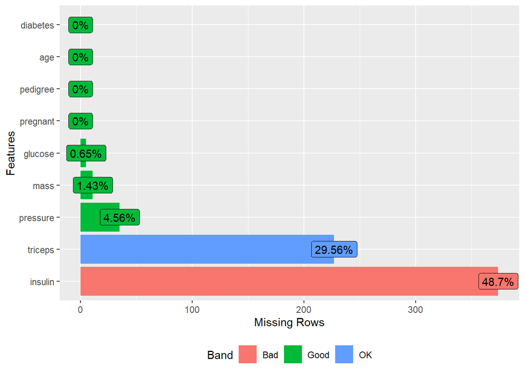

```r
DataExplorer::plot_missing(df)
```

Provo a vedere anche quali sono le variabili più correlate per capire se sia necessario conservare o meno insulin e triceps.

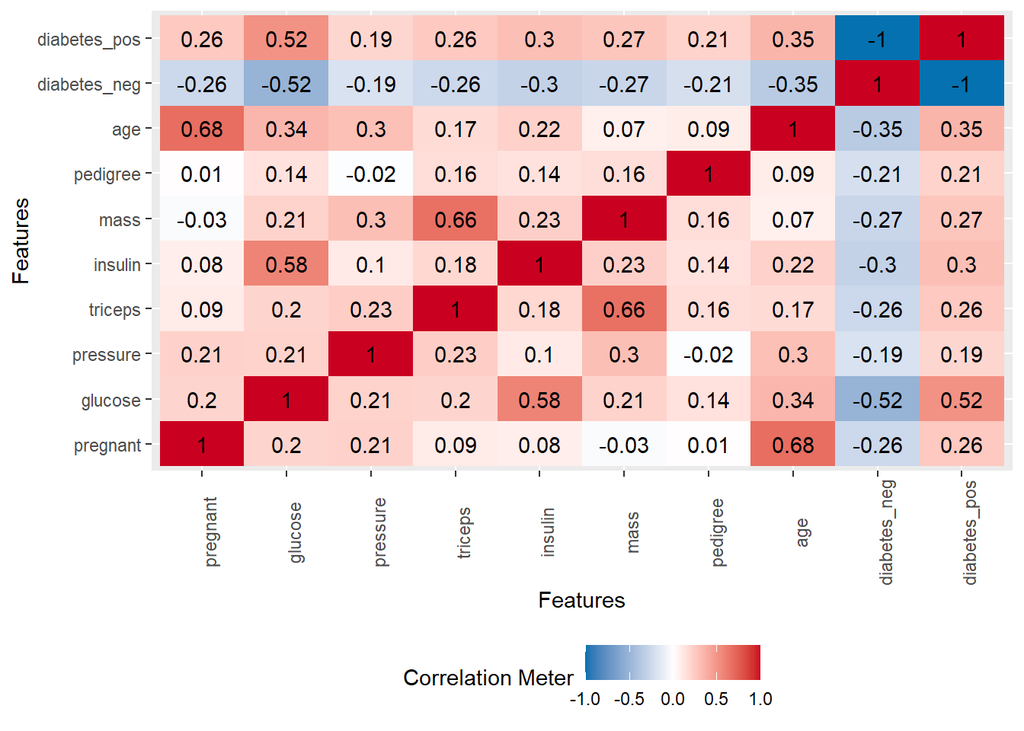

```r
DataExplorer::plot_correlation(df %>% na.omit)
```

```r
scoreNA = sapply(1:ncol(df),function(c) sum(is.na(df[,c])))
names(scoreNA) = names(df)
scoreNA
```

```
## pregnant  glucose pressure  triceps  insulin     mass pedigree      age
##        0        5       35      227      374       11        0        0
## diabetes
##        0
```

Un altro metodo può essere quello di costruire diversi GLM ma con diversi parametri inclusi e allo stesso tempo diversi dati, in quanto quando includo alcuni parametri non potrò usare i dati che non possiedono i valori per quei determinati parametri. Questa procedura risulta essere però, molto laboriosa.

Si procede allora alla creazione di una funzione, che come `stepAIC` della libreria `MASS` in versione *backward*, parte da un modello contenente tutte le variabili e successivamente rimuove quelle con più NA. La funzione creata è stata generalizzata per lavorare su diversi modelli, non solo GLM, ma anche LM e GAM. Ha, tuttavia, molte limitazioni, come l’incapacità d inserire splines, polinomiali e simili sulle variabili indipendenti. Un’altra limitazione è la mancanza di un partizionamento dei dati e successivamente di un metodo di validazione del modello.

Infine, eseguendo la funzione, il modello migliore secondo il criterio d’informazione di Akaike risulta essere il primo, ovvero il modello completo.

```r
eliminaVariabiliNA = function(funzioneModello = glm,
                              variabileRisposta,
                              dataframe,
                              famiglia,
                              variabiliFunzione = new.env(),
                              modelli = new.env())
{
  if(length(variabiliFunzione$passo) == 0) # passo 0
  {
    variabiliFunzione$passo = 0

    # costruisco una tabella con il numero di NA per ciascua variabile indipendente
    colonne = c(1:ncol(dataframe))[names(dataframe) != variabileRisposta]
    variabiliFunzione$scoreNA = sapply(colonne,function(c) sum(is.na(dataframe[,c])))
    names(variabiliFunzione$scoreNA) = names(dataframe)[names(dataframe)!=variabileRisposta]

    # definisco gli argomenti da inserire all'interno della funzione in base a ciò che ho in input, nel lm non serve la famiglia
    if(length(famiglia)>0)
    {
      variabiliFunzione$argomenti = list(formula = as.formula(paste(variabileRisposta," ~ .")),
                                         data = dataframe,
                                         family = famiglia)
    }else
    {
      variabiliFunzione$argomenti = list(formula = as.formula(paste(variabileRisposta," ~ .")),
                                         data = dataframe)
    }

    modello =  do.call(funzioneModello,list(formula = as.formula(paste(variabileRisposta," ~ .")),
                                         data = dataframe,
                                         family = binomial(link = logit)))
  }else # passo N
  {
    variabiliFunzione$argomenti$formula = modelli$formula[[variabiliFunzione$passo]]
    # rimuovo la variabile con più NA presente nel modello precedente
    modello = update(object = do.call(funzioneModello, variabiliFunzione$argomenti),
                     sprintf(". ~ . - %s",
                             deparse(as.name(names(sort(scoreNA, T)[variabiliFunzione$passo])))))
  }

  # incapsulo le informazioni più interessanti del modello
    modelli$AIC = append(modelli$AIC,modello$aic)
    modelli$coefficients = append(modelli$coefficients,modello$coefficients)
    modelli$formula = append(modelli$formula,modello$formula)
    modelli$deviance = append(modelli$deviance,modello$deviance)

    variabiliFunzione$passo = variabiliFunzione$passo + 1

    if(variabiliFunzione$passo < length(variabiliFunzione$scoreNA))
    {
      return(eliminaVariabiliNA(funzioneModello,
                                variabileRisposta,
                                dataframe,
                                famiglia,
                                variabiliFunzione,
                                modelli)) # ricorsività (richiamo del passo N+1)
    }else
    {
      return(modelli)
    }
}

modGlmNa = eliminaVariabiliNA(glm,"diabetes",df,binomial(logit))

modGlmNa$AIC
```

```
## [1] 362.0212 482.3223 686.8611 715.2412 760.4366 925.2260 935.1037 954.7203
```

### Idea

Un’idea per ottenere un modello più performante disponibile potrebbe essere quella di generare diversi modelli con diverse variabili dipendenti e in base alla variabile risposta da predire si sceglierà il modello con le features della variabile risposta.

## Riempimento NA mancanti

Essendo che il modello scelto possiede molti NA conviene fare un riempimento dei NA ove possibile. Prima di fare ciò osservo come sono distribuiti i NA nelle singole osseervazioni tra le variabili. Noto che in quasi tutti i casi i NA sono “nidificati tra le variabili”, ovvero che se `pressure` mancherà, allora di conseguenza mancheranno anche `insuline` e `triceps`.

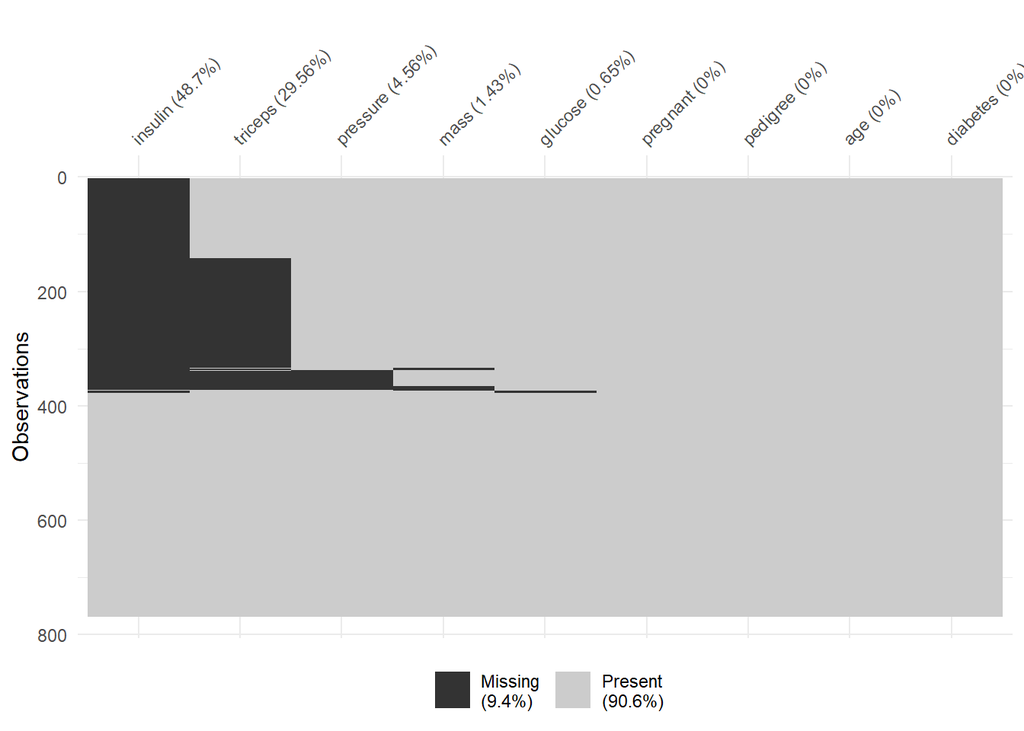

```r
vis_miss(df, sort_miss = T, cluster = T)
```

Questa tabella aiuta a vedere le correlazioni tra le variabili e che tipo di modello sarebbe più adatto stimare.

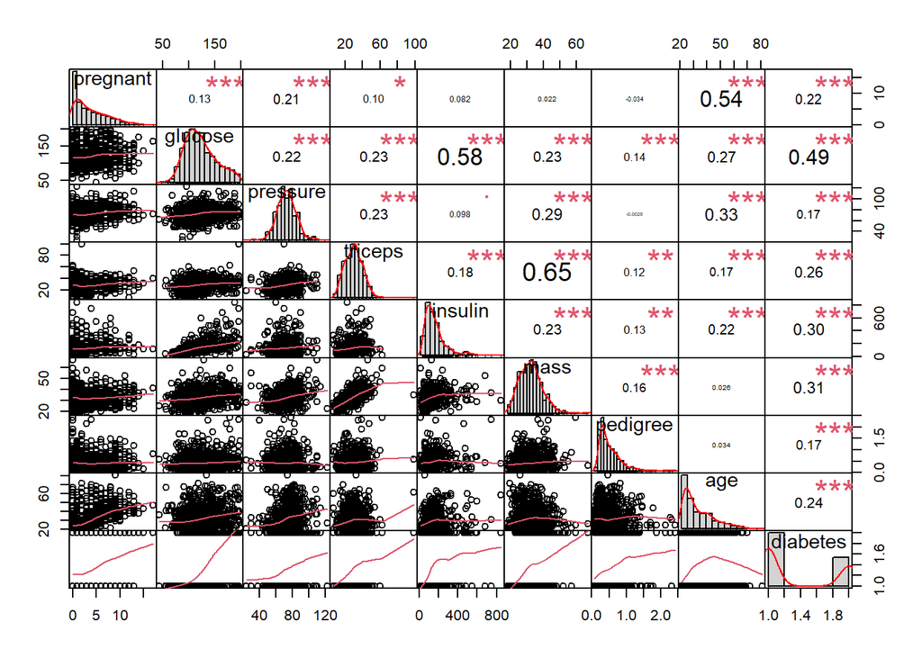

```r
PerformanceAnalytics::chart.Correlation(df %>% mutate_at("diabetes",as.numeric))
```

Il grafico sopra raffigura le correlazzioni tra variabili, le loro distribuzioni e le loro distribuzioini in funzione delle altre variabili.

#### Glucose

Partendo dalla variabile `glucose`, l’obbiettivo è quello di riempire i NA in base ai dati che abbiamo. Si nota che `glucose` è correlata con tutte le altre variabili, quindi presumibilmente il modello conterrà tutte le altre variabili. C’è anche multicollinearità, ma nessuna collinearità esatta, quindi sarebbe opportuno anche inserire la correlazione tra le variabili esplicative. L’obbiettivo è la previsione, più accurata possibile, degli NA e non l’interpretabilità del modello, infatti inserendo l’interazione il modello avrà molti stimatori in più. Per semplicità, è stato scelto un modello di regressione lineare.

```r
varDip = "glucose"
colonne = names(df)[names(df) != varDip]
modGlu = lm(as.formula(paste(varDip," ~ ",paste(colonne,collapse = " * "))), data = df)
modGlu %>% summary
```

```
##
## Call:
## lm(formula = as.formula(paste(varDip, " ~ ", paste(colonne, collapse = " * "))),
##     data = df)
##
## Residuals:
##     Min      1Q  Median      3Q     Max
## -27.086  -3.292  -0.099   3.066  74.325
##
## Coefficients:
##                                                                   Estimate
## (Intercept)                                                     -1.809e+04
## pregnant                                                         5.234e+03
## pressure                                                         2.404e+02
## triceps                                                          4.608e+02
## insulin                                                          1.439e+02
## mass                                                             4.947e+02
## pedigree                                                         2.876e+04
## age                                                              8.920e+02
## diabetespos                                                      6.105e+05
## pregnant:pressure                                               -6.815e+01
## pregnant:triceps                                                -1.464e+02
## pressure:triceps                                                -5.516e+00
## pregnant:insulin                                                -4.703e+01
## pressure:insulin                                                -2.093e+00
## triceps:insulin                                                 -3.825e+00
## pregnant:mass                                                   -1.441e+02
## pressure:mass                                                   -6.675e+00
## triceps:mass                                                    -1.082e+01
## insulin:mass                                                    -3.799e+00
## pregnant:pedigree                                               -1.053e+04
## pressure:pedigree                                               -3.447e+02
## triceps:pedigree                                                -4.080e+02
## insulin:pedigree                                                -2.311e+02
## mass:pedigree                                                   -8.387e+02
## pregnant:age                                                    -2.516e+02
## pressure:age                                                    -1.195e+01
## triceps:age                                                     -2.374e+01
## insulin:age                                                     -7.187e+00
## mass:age                                                        -2.516e+01
```

[output cut: 990 more lines]

```
## pregnant:pressure:triceps:insulin:mass:pedigree:diabetespos       0.5507
## pregnant:pressure:triceps:insulin:mass:age:diabetespos            0.1546
## pregnant:pressure:triceps:insulin:pedigree:age:diabetespos        0.1764
## pregnant:pressure:triceps:mass:pedigree:age:diabetespos           0.0687 .
## pregnant:pressure:insulin:mass:pedigree:age:diabetespos           0.0314 *
## pregnant:triceps:insulin:mass:pedigree:age:diabetespos            0.1142
## pressure:triceps:insulin:mass:pedigree:age:diabetespos            0.1110
## pregnant:pressure:triceps:insulin:mass:pedigree:age:diabetespos   0.1179
## ---
## Signif. codes:  0 '***' 0.001 '**' 0.01 '*' 0.05 '.' 0.1 ' ' 1
##
## Residual standard error: 16.68 on 136 degrees of freedom
##   (376 osservazioni eliminate a causa di valori mancanti)
## Multiple R-squared:  0.8984, Adjusted R-squared:  0.7078
## F-statistic: 4.715 on 255 and 136 DF,  p-value: < 2.2e-16
```

Come si può osservare il modello non è interpretabile ma garantisceun buon $R^2_{adj}$. Eseguendo un modello senza interazioni si otterebbe un $R^2_{adj}$ del 47% contro il 70% di quello con interazioni. Anche seguendo il criterio dell’informazione di Akaike scegliamo il modello con interazioni. Interessante anche notare come la differenza tra $R^2_{adj}$ e $R^2$ nel modello con interazioni, in quanto contiene molti più parametri confronto il modello con interazioni, dove la differenza è nettamente minore.

```r
modGluSemplice = lm(as.formula(paste(varDip, " ~ ",paste(colonne,collapse = " + "))), df)
data.frame(R2 = c(summary(modGlu)$r.squared, summary(modGluSemplice)$r.squared),
           R2adj = c(summary(modGlu)$adj.r.squared, summary(modGluSemplice)$adj.r.squared),
           AIC = c(AIC(modGlu), AIC(modGluSemplice)),
           row.names = c("Con interazioni", "Senza interazioni"))
```

|  | R2 | R2adj | AIC |
| --- | --- | --- | --- |
| Con interazioni | 0.8983807 | 0.7078444 | 3417.847 |
| Senza interazioni | 0.4843020 | 0.4735302 | 3560.568 |

Nel modello conviene non includere le variabili le quali hanno degli NA sia nella suddetta variabile, sia nella variabile risposta. Un’altra opzione è quella di costruire modelli ad hoc in base alle informazioni disponibili sull’osservazione con NA nella variabile risposta.

```r
righeNA = is.na(df$glucose)
df[righeNA,]
```

| pregnant | glucose | pressure | triceps | insulin | mass | pedigree | age | diabetes |
| --- | --- | --- | --- | --- | --- | --- | --- | --- |
| 1 | NA | 48 | 20 | NA | 24.7 | 0.140 | 22 | neg |
| 1 | NA | 74 | 20 | 23 | 27.7 | 0.299 | 21 | neg |
| 1 | NA | 68 | 35 | NA | 32.0 | 0.389 | 22 | neg |
| 5 | NA | 80 | 32 | NA | 41.0 | 0.346 | 37 | pos |
| 6 | NA | 68 | 41 | NA | 39.0 | 0.727 | 41 | pos |

```r
colonne = names(df)[!sapply(1:ncol(df), function(c) sum(is.na(df[,varDip]) & is.na(df[,c]))>0)]
# seleziona le righe con almeno un NA oltre la variabile dipendente e su di esse applica un modello senza le colonne le quali contengono NA nella stessa osservazione con NA sulla variabile dipendente
righe = sapply(1:nrow(df), function(r) sum(sapply(1:ncol(df), function(c) is.na(df[,varDip]) & is.na(df[,c]))[r,]))>1
df[righe,varDip] = predict(lm(as.formula(paste(varDip, " ~ ",paste(colonne,collapse = " + "))), df),
                     newdata = df[righe,])

# modello completo
righe = sapply(1:nrow(df), function(r) sum(sapply(1:ncol(df), function(c) is.na(df[,varDip]) & is.na(df[,c]))[r,])) == 1
df[righe,varDip] = predict(modGlu, newdata = df[righe,])
df[righeNA,]
```

| pregnant | glucose | pressure | triceps | insulin | mass | pedigree | age | diabetes |
| --- | --- | --- | --- | --- | --- | --- | --- | --- |
| 1 | 100.60264 | 48 | 20 | NA | 24.7 | 0.140 | 22 | neg |
| 1 | 87.22566 | 74 | 20 | 23 | 27.7 | 0.299 | 21 | neg |
| 1 | 109.06082 | 68 | 35 | NA | 32.0 | 0.389 | 22 | neg |
| 5 | 144.03169 | 80 | 32 | NA | 41.0 | 0.346 | 37 | pos |
| 6 | 144.92741 | 68 | 41 | NA | 39.0 | 0.727 | 41 | pos |

#### Mass

Ora ripeto la procedura con la variabile `Mass`.

```
## Start:  AIC=1248.26
## mass ~ pregnant * glucose * pressure * triceps * insulin * pedigree *
##     age * diabetes
##
##                                                                   Df Sum of Sq
## - pregnant:glucose:pressure:triceps:insulin:pedigree:age:diabetes  1    12.052
## <none>
##                                                                      RSS    AIC
## - pregnant:glucose:pressure:triceps:insulin:pedigree:age:diabetes 2570.8 1248.1
## <none>                                                            2558.7 1248.3
##
## Step:  AIC=1248.11
## mass ~ pregnant + glucose + pressure + triceps + insulin + pedigree +
##     age + diabetes + pregnant:glucose + pregnant:pressure + glucose:pressure +
##     pregnant:triceps + glucose:triceps + pressure:triceps + pregnant:insulin +
##     glucose:insulin + pressure:insulin + triceps:insulin + pregnant:pedigree +
##     glucose:pedigree + pressure:pedigree + triceps:pedigree +
##     insulin:pedigree + pregnant:age + glucose:age + pressure:age +
##     triceps:age + insulin:age + pedigree:age + pregnant:diabetes +
##     glucose:diabetes + pressure:diabetes + triceps:diabetes +
##     insulin:diabetes + pedigree:diabetes + age:diabetes + pregnant:glucose:pressure +
##     pregnant:glucose:triceps + pregnant:pressure:triceps + glucose:pressure:triceps +
##     pregnant:glucose:insulin + pregnant:pressure:insulin + glucose:pressure:insulin +
##     pregnant:triceps:insulin + glucose:triceps:insulin + pressure:triceps:insulin +
##     pregnant:glucose:pedigree + pregnant:pressure:pedigree +
##     glucose:pressure:pedigree + pregnant:triceps:pedigree + glucose:triceps:pedigree +
##     pressure:triceps:pedigree + pregnant:insulin:pedigree + glucose:insulin:pedigree +
##     pressure:insulin:pedigree + triceps:insulin:pedigree + pregnant:glucose:age +
##     pregnant:pressure:age + glucose:pressure:age + pregnant:triceps:age +
##     glucose:triceps:age + pressure:triceps:age + pregnant:insulin:age +
##     glucose:insulin:age + pressure:insulin:age + triceps:insulin:age +
##     pregnant:pedigree:age + glucose:pedigree:age + pressure:pedigree:age +
##     triceps:pedigree:age + insulin:pedigree:age + pregnant:glucose:diabetes +
##     pregnant:pressure:diabetes + glucose:pressure:diabetes +
##     pregnant:triceps:diabetes + glucose:triceps:diabetes + pressure:triceps:diabetes +
##     pregnant:insulin:diabetes + glucose:insulin:diabetes + pressure:insulin:diabetes +
##     triceps:insulin:diabetes + pregnant:pedigree:diabetes + glucose:pedigree:diabetes +
##     pressure:pedigree:diabetes + triceps:pedigree:diabetes +
##     insulin:pedigree:diabetes + pregnant:age:diabetes + glucose:age:diabetes +
##     pressure:age:diabetes + triceps:age:diabetes + insulin:age:diabetes +
```

[output cut: 620 more lines]

```
## - pregnant:glucose:triceps:pedigree:age:diabetes               1    52.793
## - pregnant:glucose:pressure:triceps:insulin:age:diabetes       1    57.405
## - pregnant:glucose:pressure:triceps:insulin:pedigree:age       1    73.883
## - pregnant:glucose:pressure:triceps:insulin:pedigree:diabetes  1    82.395
## - pregnant:glucose:pressure:insulin:pedigree:age:diabetes      1    87.274
## - glucose:pressure:triceps:insulin:pedigree:age:diabetes       1    87.532
##                                                                  RSS    AIC
## <none>                                                        2594.0 1243.7
## - pregnant:pressure:triceps:pedigree:age:diabetes             2619.4 1245.5
## - pregnant:glucose:triceps:pedigree:age:diabetes              2646.8 1249.6
## - pregnant:glucose:pressure:triceps:insulin:age:diabetes      2651.4 1250.2
## - pregnant:glucose:pressure:triceps:insulin:pedigree:age      2667.9 1252.7
## - pregnant:glucose:pressure:triceps:insulin:pedigree:diabetes 2676.4 1253.9
## - pregnant:glucose:pressure:insulin:pedigree:age:diabetes     2681.2 1254.7
## - glucose:pressure:triceps:insulin:pedigree:age:diabetes      2681.5 1254.7
```

```r
summary(modMass)$adj.r.squared
```

```
## [1] 0.6297323
```

##### Classificazione NA

Il problema è che bisogna fare diversi modelli per i diversi casi di NA nelle altree variabili, procedo allora con una iniziale classificazione

```r
naDf = as.data.frame(sapply(1:ncol(df),
                            function(c) is.na(df[,varDip]) & is.na(df[,c])))
names(naDf) = names(df)
# seleziono le colonne con almeno un NA
naDf = naDf[,sapply(1:ncol(naDf), function(c) sum(naDf[,c])>0)]
ftable(xtabs(mass ~ ., naDf))
```

```
##                  insulin FALSE TRUE
## pressure triceps
## FALSE    FALSE               1    1
##          TRUE                0    2
## TRUE     FALSE               0    0
##          TRUE                0    7
```

I modelli da costruire saranno 4.. Il codice di seguito prende un’osservazione NA, costruisce un modello escludendo altre variabili NA nella stessa osservazione e successivamente, attraverso il modello, predice il valora della variabile NA e lo sostituisce. Ovviamente non lo fa solo alla singola osservazione ma a tutte le osservazioni che si troveranno nella medesima situazione.

```
## Start:  AIC=2690.25
## mass ~ pregnant * glucose * pressure * pedigree * age * diabetes
##
##                                                   Df Sum of Sq   RSS    AIC
## - pregnant:glucose:pressure:pedigree:age:diabetes  1    30.686 24531 2689.2
## <none>                                                         24500 2690.2
##
## Step:  AIC=2689.16
## mass ~ pregnant + glucose + pressure + pedigree + age + diabetes +
##     pregnant:glucose + pregnant:pressure + glucose:pressure +
##     pregnant:pedigree + glucose:pedigree + pressure:pedigree +
##     pregnant:age + glucose:age + pressure:age + pedigree:age +
##     pregnant:diabetes + glucose:diabetes + pressure:diabetes +
##     pedigree:diabetes + age:diabetes + pregnant:glucose:pressure +
##     pregnant:glucose:pedigree + pregnant:pressure:pedigree +
##     glucose:pressure:pedigree + pregnant:glucose:age + pregnant:pressure:age +
##     glucose:pressure:age + pregnant:pedigree:age + glucose:pedigree:age +
##     pressure:pedigree:age + pregnant:glucose:diabetes + pregnant:pressure:diabetes +
##     glucose:pressure:diabetes + pregnant:pedigree:diabetes +
##     glucose:pedigree:diabetes + pressure:pedigree:diabetes +
##     pregnant:age:diabetes + glucose:age:diabetes + pressure:age:diabetes +
##     pedigree:age:diabetes + pregnant:glucose:pressure:pedigree +
##     pregnant:glucose:pressure:age + pregnant:glucose:pedigree:age +
##     pregnant:pressure:pedigree:age + glucose:pressure:pedigree:age +
##     pregnant:glucose:pressure:diabetes + pregnant:glucose:pedigree:diabetes +
##     pregnant:pressure:pedigree:diabetes + glucose:pressure:pedigree:diabetes +
##     pregnant:glucose:age:diabetes + pregnant:pressure:age:diabetes +
##     glucose:pressure:age:diabetes + pregnant:pedigree:age:diabetes +
##     glucose:pedigree:age:diabetes + pressure:pedigree:age:diabetes +
##     pregnant:glucose:pressure:pedigree:age + pregnant:glucose:pressure:pedigree:diabetes +
##     pregnant:glucose:pressure:age:diabetes + pregnant:glucose:pedigree:age:diabetes +
##     pregnant:pressure:pedigree:age:diabetes + glucose:pressure:pedigree:age:diabetes
##
##                                               Df Sum of Sq   RSS    AIC
## - pregnant:glucose:pressure:pedigree:age       1     0.080 24531 2687.2
## - pregnant:glucose:pressure:age:diabetes       1     4.791 24535 2687.3
## - pregnant:pressure:pedigree:age:diabetes      1     9.505 24540 2687.4
## <none>                                                     24531 2689.2
## - glucose:pressure:pedigree:age:diabetes       1    81.857 24612 2689.6
## - pregnant:glucose:pedigree:age:diabetes       1   124.620 24655 2690.9
```

[output cut: 900 more lines]

```
## - pregnant:glucose:triceps:pedigree:age:diabetes               1    52.793
## - pregnant:glucose:pressure:triceps:insulin:age:diabetes       1    57.405
## - pregnant:glucose:pressure:triceps:insulin:pedigree:age       1    73.883
## - pregnant:glucose:pressure:triceps:insulin:pedigree:diabetes  1    82.395
## - pregnant:glucose:pressure:insulin:pedigree:age:diabetes      1    87.274
## - glucose:pressure:triceps:insulin:pedigree:age:diabetes       1    87.532
##                                                                  RSS    AIC
## <none>                                                        2594.0 1243.7
## - pregnant:pressure:triceps:pedigree:age:diabetes             2619.4 1245.5
## - pregnant:glucose:triceps:pedigree:age:diabetes              2646.8 1249.6
## - pregnant:glucose:pressure:triceps:insulin:age:diabetes      2651.4 1250.2
## - pregnant:glucose:pressure:triceps:insulin:pedigree:age      2667.9 1252.7
## - pregnant:glucose:pressure:triceps:insulin:pedigree:diabetes 2676.4 1253.9
## - pregnant:glucose:pressure:insulin:pedigree:age:diabetes     2681.2 1254.7
## - glucose:pressure:triceps:insulin:pedigree:age:diabetes      2681.5 1254.7
```

#### Pressure

```
## Start:  AIC=2008.65
## pressure ~ pregnant * glucose * triceps * insulin * mass * pedigree *
##     age * diabetes
##
##                                                               Df Sum of Sq
## <none>
## - pregnant:glucose:triceps:insulin:mass:pedigree:age:diabetes  1    126.97
##                                                                 RSS    AIC
## <none>                                                        17588 2008.7
## - pregnant:glucose:triceps:insulin:mass:pedigree:age:diabetes 17715 2009.5
```

```r
naDf = as.data.frame(sapply(1:ncol(df),
                            function(c) is.na(df[,varDip]) & is.na(df[,c])))
names(naDf) = names(df)
# seleziono le colonne con almeno un NA
naDf = naDf[,sapply(1:ncol(naDf), function(c) sum(naDf[,c])>0)]
ftable(xtabs(get(varDip) ~ ., naDf))
```

```
##                  insulin FALSE TRUE
## pressure triceps
## FALSE    FALSE               0    0
##          TRUE                0    0
## TRUE     FALSE               0    2
##          TRUE                0   33
```

```
## Start:  AIC=3580.45
## pressure ~ pregnant * glucose * mass * pedigree * age * diabetes
##
##                                               Df Sum of Sq   RSS    AIC
## - pregnant:glucose:mass:pedigree:age:diabetes  1    43.863 81447 3578.8
## <none>                                                     81403 3580.4
##
## Step:  AIC=3578.84
## pressure ~ pregnant + glucose + mass + pedigree + age + diabetes +
##     pregnant:glucose + pregnant:mass + glucose:mass + pregnant:pedigree +
##     glucose:pedigree + mass:pedigree + pregnant:age + glucose:age +
##     mass:age + pedigree:age + pregnant:diabetes + glucose:diabetes +
##     mass:diabetes + pedigree:diabetes + age:diabetes + pregnant:glucose:mass +
##     pregnant:glucose:pedigree + pregnant:mass:pedigree + glucose:mass:pedigree +
##     pregnant:glucose:age + pregnant:mass:age + glucose:mass:age +
##     pregnant:pedigree:age + glucose:pedigree:age + mass:pedigree:age +
##     pregnant:glucose:diabetes + pregnant:mass:diabetes + glucose:mass:diabetes +
##     pregnant:pedigree:diabetes + glucose:pedigree:diabetes +
##     mass:pedigree:diabetes + pregnant:age:diabetes + glucose:age:diabetes +
##     mass:age:diabetes + pedigree:age:diabetes + pregnant:glucose:mass:pedigree +
##     pregnant:glucose:mass:age + pregnant:glucose:pedigree:age +
##     pregnant:mass:pedigree:age + glucose:mass:pedigree:age +
##     pregnant:glucose:mass:diabetes + pregnant:glucose:pedigree:diabetes +
##     pregnant:mass:pedigree:diabetes + glucose:mass:pedigree:diabetes +
##     pregnant:glucose:age:diabetes + pregnant:mass:age:diabetes +
##     glucose:mass:age:diabetes + pregnant:pedigree:age:diabetes +
##     glucose:pedigree:age:diabetes + mass:pedigree:age:diabetes +
##     pregnant:glucose:mass:pedigree:age + pregnant:glucose:mass:pedigree:diabetes +
##     pregnant:glucose:mass:age:diabetes + pregnant:glucose:pedigree:age:diabetes +
##     pregnant:mass:pedigree:age:diabetes + glucose:mass:pedigree:age:diabetes
##
##                                           Df Sum of Sq   RSS    AIC
## - glucose:mass:pedigree:age:diabetes       1      6.36 81453 3576.9
## - pregnant:glucose:mass:age:diabetes       1     27.84 81475 3577.1
## - pregnant:glucose:mass:pedigree:diabetes  1     63.83 81511 3577.4
## - pregnant:glucose:pedigree:age:diabetes   1    141.12 81588 3578.1
## <none>                                                 81447 3578.8
## - pregnant:mass:pedigree:age:diabetes      1    252.26 81699 3579.1
## - pregnant:glucose:mass:pedigree:age       1    636.35 82083 3582.5
##
```

[output cut: 308 more lines]

```
##     mass:pedigree:age:diabetes + pregnant:glucose:mass:pedigree:age +
##     pregnant:mass:pedigree:age:diabetes
##
##                                       Df Sum of Sq   RSS    AIC
## <none>                                             81937 3561.2
## - glucose:mass:pedigree:diabetes       1    241.07 82178 3561.4
## - pregnant:mass:pedigree:age:diabetes  1    460.68 82398 3563.4
## - pregnant:glucose:mass:pedigree:age   1   1001.54 82939 3568.1
## Start:  AIC=2692.64
## pressure ~ pregnant * glucose * triceps * mass * pedigree * age *
##     diabetes
##
##                                                       Df Sum of Sq   RSS    AIC
## <none>                                                             49533 2692.6
## - pregnant:glucose:triceps:mass:pedigree:age:diabetes  1    191.45 49724 2692.7
```

#### Triceps

```
## Start:  AIC=1673.66
## triceps ~ pregnant * glucose * pressure * insulin * mass * pedigree *
##     age * diabetes
##
##                                                                Df Sum of Sq
## - pregnant:glucose:pressure:insulin:mass:pedigree:age:diabetes  1    7.7648
## <none>
##                                                                   RSS    AIC
## - pregnant:glucose:pressure:insulin:mass:pedigree:age:diabetes 7523.3 1672.1
## <none>                                                         7515.5 1673.7
##
## Step:  AIC=1672.07
## triceps ~ pregnant + glucose + pressure + insulin + mass + pedigree +
##     age + diabetes + pregnant:glucose + pregnant:pressure + glucose:pressure +
##     pregnant:insulin + glucose:insulin + pressure:insulin + pregnant:mass +
##     glucose:mass + pressure:mass + insulin:mass + pregnant:pedigree +
##     glucose:pedigree + pressure:pedigree + insulin:pedigree +
##     mass:pedigree + pregnant:age + glucose:age + pressure:age +
##     insulin:age + mass:age + pedigree:age + pregnant:diabetes +
##     glucose:diabetes + pressure:diabetes + insulin:diabetes +
##     mass:diabetes + pedigree:diabetes + age:diabetes + pregnant:glucose:pressure +
##     pregnant:glucose:insulin + pregnant:pressure:insulin + glucose:pressure:insulin +
##     pregnant:glucose:mass + pregnant:pressure:mass + glucose:pressure:mass +
##     pregnant:insulin:mass + glucose:insulin:mass + pressure:insulin:mass +
##     pregnant:glucose:pedigree + pregnant:pressure:pedigree +
##     glucose:pressure:pedigree + pregnant:insulin:pedigree + glucose:insulin:pedigree +
##     pressure:insulin:pedigree + pregnant:mass:pedigree + glucose:mass:pedigree +
##     pressure:mass:pedigree + insulin:mass:pedigree + pregnant:glucose:age +
##     pregnant:pressure:age + glucose:pressure:age + pregnant:insulin:age +
##     glucose:insulin:age + pressure:insulin:age + pregnant:mass:age +
##     glucose:mass:age + pressure:mass:age + insulin:mass:age +
##     pregnant:pedigree:age + glucose:pedigree:age + pressure:pedigree:age +
##     insulin:pedigree:age + mass:pedigree:age + pregnant:glucose:diabetes +
##     pregnant:pressure:diabetes + glucose:pressure:diabetes +
##     pregnant:insulin:diabetes + glucose:insulin:diabetes + pressure:insulin:diabetes +
##     pregnant:mass:diabetes + glucose:mass:diabetes + pressure:mass:diabetes +
##     insulin:mass:diabetes + pregnant:pedigree:diabetes + glucose:pedigree:diabetes +
##     pressure:pedigree:diabetes + insulin:pedigree:diabetes +
##     mass:pedigree:diabetes + pregnant:age:diabetes + glucose:age:diabetes +
##     pressure:age:diabetes + insulin:age:diabetes + mass:age:diabetes +
```

[output cut: 477 more lines]

```
## - pregnant:glucose:pressure:insulin:mass:pedigree:age       1    116.53 7675.5
## - pregnant:glucose:insulin:mass:pedigree:age:diabetes       1    158.86 7717.9
## - pregnant:glucose:pressure:insulin:pedigree:age:diabetes   1    212.46 7771.5
## - pressure:insulin:mass:pedigree:age:diabetes               1    297.51 7856.5
## - pregnant:pressure:mass:pedigree:age:diabetes              1    863.19 8422.2
##                                                               AIC
## <none>                                                     1667.9
## - pregnant:glucose:pressure:insulin:mass:age:diabetes      1668.3
## - glucose:pressure:mass:pedigree:age:diabetes              1670.2
## - pregnant:glucose:pressure:insulin:mass:pedigree:diabetes 1670.8
## - pregnant:glucose:pressure:insulin:mass:pedigree:age      1672.0
## - pregnant:glucose:insulin:mass:pedigree:age:diabetes      1674.1
## - pregnant:glucose:pressure:insulin:pedigree:age:diabetes  1676.8
## - pressure:insulin:mass:pedigree:age:diabetes              1681.1
## - pregnant:pressure:mass:pedigree:age:diabetes             1708.5
```

```
## Start:  AIC=2295.11
## triceps ~ pregnant * glucose * pressure * mass * pedigree * age *
##     diabetes
##
##                                                        Df Sum of Sq   RSS
## - pregnant:glucose:pressure:mass:pedigree:age:diabetes  1    4.5938 23453
## <none>                                                              23449
##                                                           AIC
## - pregnant:glucose:pressure:mass:pedigree:age:diabetes 2293.2
## <none>                                                 2295.1
##
## Step:  AIC=2293.22
## triceps ~ pregnant + glucose + pressure + mass + pedigree + age +
##     diabetes + pregnant:glucose + pregnant:pressure + glucose:pressure +
##     pregnant:mass + glucose:mass + pressure:mass + pregnant:pedigree +
##     glucose:pedigree + pressure:pedigree + mass:pedigree + pregnant:age +
##     glucose:age + pressure:age + mass:age + pedigree:age + pregnant:diabetes +
##     glucose:diabetes + pressure:diabetes + mass:diabetes + pedigree:diabetes +
##     age:diabetes + pregnant:glucose:pressure + pregnant:glucose:mass +
##     pregnant:pressure:mass + glucose:pressure:mass + pregnant:glucose:pedigree +
##     pregnant:pressure:pedigree + glucose:pressure:pedigree +
##     pregnant:mass:pedigree + glucose:mass:pedigree + pressure:mass:pedigree +
##     pregnant:glucose:age + pregnant:pressure:age + glucose:pressure:age +
##     pregnant:mass:age + glucose:mass:age + pressure:mass:age +
##     pregnant:pedigree:age + glucose:pedigree:age + pressure:pedigree:age +
##     mass:pedigree:age + pregnant:glucose:diabetes + pregnant:pressure:diabetes +
##     glucose:pressure:diabetes + pregnant:mass:diabetes + glucose:mass:diabetes +
##     pressure:mass:diabetes + pregnant:pedigree:diabetes + glucose:pedigree:diabetes +
##     pressure:pedigree:diabetes + mass:pedigree:diabetes + pregnant:age:diabetes +
##     glucose:age:diabetes + pressure:age:diabetes + mass:age:diabetes +
##     pedigree:age:diabetes + pregnant:glucose:pressure:mass +
##     pregnant:glucose:pressure:pedigree + pregnant:glucose:mass:pedigree +
##     pregnant:pressure:mass:pedigree + glucose:pressure:mass:pedigree +
##     pregnant:glucose:pressure:age + pregnant:glucose:mass:age +
##     pregnant:pressure:mass:age + glucose:pressure:mass:age +
##     pregnant:glucose:pedigree:age + pregnant:pressure:pedigree:age +
##     glucose:pressure:pedigree:age + pregnant:mass:pedigree:age +
##     glucose:mass:pedigree:age + pressure:mass:pedigree:age +
##     pregnant:glucose:pressure:diabetes + pregnant:glucose:mass:diabetes +
##     pregnant:pressure:mass:diabetes + glucose:pressure:mass:diabetes +
```

[output cut: 776 more lines]

```
##     pregnant:pressure:mass:pedigree:diabetes + glucose:pressure:mass:pedigree:diabetes +
##     pregnant:glucose:pressure:age:diabetes + pregnant:glucose:mass:age:diabetes +
##     pregnant:pressure:mass:age:diabetes + glucose:pressure:mass:age:diabetes +
##     glucose:pressure:pedigree:age:diabetes + glucose:mass:pedigree:age:diabetes +
##     pressure:mass:pedigree:age:diabetes + pregnant:glucose:pressure:mass:age:diabetes +
##     glucose:pressure:mass:pedigree:age:diabetes
##
##                                               Df Sum of Sq   RSS    AIC
## <none>                                                     23878 2276.9
## - glucose:pressure:mass:pedigree:age:diabetes  1    125.61 24004 2277.8
## - pregnant:glucose:mass:pedigree:diabetes      1    134.62 24013 2278.0
## - pregnant:pressure:mass:pedigree:diabetes     1    156.76 24035 2278.5
## - pregnant:glucose:pressure:mass:age:diabetes  1    177.98 24056 2278.9
## - pregnant:pressure:mass:pedigree:age          1    203.69 24082 2279.5
## - pregnant:glucose:pressure:pedigree:diabetes  1    370.87 24249 2283.3
```

#### Insulin

Nell’ultimo caso basta fare un unico modello. OOra tutti gli NA sono stati corretti.

```r
varDip = "insulin"
colonne = names(df)[names(df) != varDip]
modMass = MASS::stepAIC(lm(as.formula(paste(varDip," ~ ",paste(colonne,collapse = " * "))), data = df))
```

```
## Start:  AIC=3339.49
## insulin ~ pregnant * glucose * pressure * triceps * mass * pedigree *
##     age * diabetes
##
##                                                                Df Sum of Sq
## <none>
## - pregnant:glucose:pressure:triceps:mass:pedigree:age:diabetes  1     12159
##                                                                   RSS    AIC
## <none>                                                         515410 3339.5
## - pregnant:glucose:pressure:triceps:mass:pedigree:age:diabetes 527570 3346.7
```

```r
righe = is.na(df[,varDip])

df[righe,varDip] = predict(modMass, newdata = df[righe,])

anyNA.data.frame(df)
```

```
## [1] FALSE
```

## Modello glm

Il modello senza le modifiche sugli NA è il seguente:

```r
modGlmNA = glm(diabetes ~ ., family = binomial, data = PimaIndiansDiabetes2)
summary(modGlmNA)
```

```
##
## Call:
## glm(formula = diabetes ~ ., family = binomial, data = PimaIndiansDiabetes2)
##
## Deviance Residuals:
##     Min       1Q   Median       3Q      Max
## -2.7823  -0.6603  -0.3642   0.6409   2.5612
##
## Coefficients:
##               Estimate Std. Error z value Pr(>|z|)
## (Intercept) -1.004e+01  1.218e+00  -8.246  < 2e-16 ***
## pregnant     8.216e-02  5.543e-02   1.482  0.13825
## glucose      3.827e-02  5.768e-03   6.635 3.24e-11 ***
## pressure    -1.420e-03  1.183e-02  -0.120  0.90446
## triceps      1.122e-02  1.708e-02   0.657  0.51128
## insulin     -8.253e-04  1.306e-03  -0.632  0.52757
## mass         7.054e-02  2.734e-02   2.580  0.00989 **
## pedigree     1.141e+00  4.274e-01   2.669  0.00760 **
## age          3.395e-02  1.838e-02   1.847  0.06474 .
## ---
## Signif. codes:  0 '***' 0.001 '**' 0.01 '*' 0.05 '.' 0.1 ' ' 1
##
## (Dispersion parameter for binomial family taken to be 1)
##
##     Null deviance: 498.10  on 391  degrees of freedom
## Residual deviance: 344.02  on 383  degrees of freedom
##   (376 osservazioni eliminate a causa di valori mancanti)
## AIC: 362.02
##
## Number of Fisher Scoring iterations: 5
```

Il seguente modello, invece, è stato prodotto con le modifichesugli NA:

```r
modGlm = glm(diabetes ~ ., family = binomial, data = df)
summary(modGlm)
```

```
##
## Call:
## glm(formula = diabetes ~ ., family = binomial, data = df)
##
## Deviance Residuals:
##     Min       1Q   Median       3Q      Max
## -2.8630  -0.7002  -0.3947   0.7050   2.4617
##
## Coefficients:
##               Estimate Std. Error z value Pr(>|z|)
## (Intercept) -9.382e+00  8.289e-01 -11.319  < 2e-16 ***
## pregnant     1.339e-01  3.303e-02   4.054 5.04e-05 ***
## glucose      3.755e-02  3.653e-03  10.279  < 2e-16 ***
## pressure    -8.373e-03  8.686e-03  -0.964  0.33506
## triceps     -2.265e-02  8.778e-03  -2.581  0.00986 **
## insulin      8.522e-06  2.141e-05   0.398  0.69067
## mass         1.172e-01  1.802e-02   6.505 7.77e-11 ***
## pedigree     9.837e-01  3.005e-01   3.274  0.00106 **
## age          1.291e-02  9.611e-03   1.344  0.17903
## ---
## Signif. codes:  0 '***' 0.001 '**' 0.01 '*' 0.05 '.' 0.1 ' ' 1
##
## (Dispersion parameter for binomial family taken to be 1)
##
##     Null deviance: 993.48  on 767  degrees of freedom
## Residual deviance: 703.75  on 759  degrees of freedom
## AIC: 721.75
##
## Number of Fisher Scoring iterations: 5
```

Fare un confronto sui due modelli tramite AIC non è opportuno in quanto sono stati utilizzati due dataset diversi, metodi migliori per testare i due modelli sono set validation, cross validation, …

```r
# LOO-CV
cv = boot::cv.glm(df, modGlm, K = nrow(df))
cvNA = boot::cv.glm(na.omit(PimaIndiansDiabetes2), modGlmNA)
data.frame("NA sistemati" = cv$delta,
           "Dati grezzi" = cvNA$delta)
```

| NA.sistemati | Dati.grezzi |
| --- | --- |
| 0.1549543 | 0.1504618 |
| 0.1549525 | 0.1504500 |

Secondo la cross validazione, metodo leave one out, il modello da scegliere è quello senza NA. Nel caso in cui sia presente un’osservazione con NA non sarà applicabile il modello, a meno che non venga fatto il “riempimento” degli NA, come fatto in precedenza.

## Costruire curva ROC

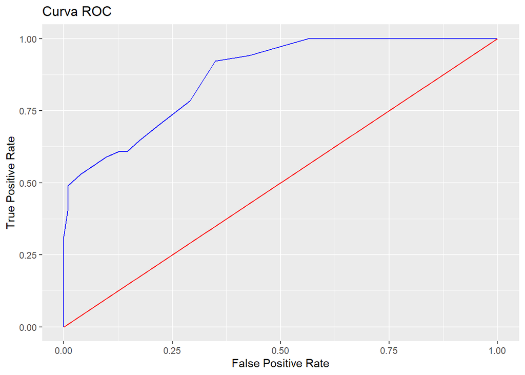

```r
# modifico l'ordine dei livelli della variabile fattoriale
df$diabetes = relevel(df$diabetes,"pos")

set.seed(1)
train = sample(1:nrow(df), .8 * nrow(df))
modGlmTrain = glm(diabetes ~ .,
                  family = binomial,
                  data = df,
                  subset = train)

pred = predict(modGlmTrain, df[-train,], type = "response")

curvaROC = function(pred, oss, dettaglio = 100)
{
  tpr = c(0)
  fpr = c(0)
  for(i in 1:(dettaglio - 1))
  {
    previsto = factor(ifelse(pred < (i/dettaglio), "pos", "neg"),
                      levels = c("pos","neg"),
                      labels = c("pos","neg"),
                      ordered = T)
    t = table(oss,previsto)
    # sono invertiti perché  nella tabella mi metteva prima i negativi e poii i positivi, in alternativa era da cambiare l'ordine dei livelli della variabile fattoriale
    if(length(t) == 4)
    {
      tpr = c(tpr, (t[1] / (t[1] + t[3])))
      fpr = c(fpr, (t[2] / (t[2] + t[4])))
    }else
    {
      tpr = c(tpr, 1)
      fpr = c(fpr, (t[1] / (t[2] + t[1])))
    }
  }
  tpr = c(tpr, 1)
  fpr = c(fpr, 1)
  return(data.frame(tpr,fpr))
}

plotROC = function(dfROC)
{
  ggplot(dfROC, aes(x = fpr, y = tpr)) +
    geom_line(color = "blue") +
    geom_line(aes(x = x, y = x),
              data = data.frame(x = c(0,1)), # non è stato utilizzato abline per limitare la linea tra 0 e 1
              color = "red") +
    labs(x = "False Positive Rate",
         y = "True Positive Rate",
         title = "Curva ROC")
}
# maggiore è il dettaglio, più la funzione sarà a scalino, minore arà la variabile dettaglio, la curva sarà più liscia (smoothies)
plotROC(curvaROC(pred, df$diabetes[-train], dettaglio = 20))
```

## Calcolare AUC

L’AUC del modello si attesta al 87%, si può affermare che è un buon modello.

```r
calcoloAUC = function(dfROC)
  return(sum(sapply(1:(length(dfROC$tpr) - 1),
                    function(i) dfROC$tpr[i + 1] * (dfROC$fpr[i+1]-dfROC$fpr[i]))))


calcoloAUC(curvaROC(pred, df$diabetes[-train], 500))
```

```
## [1] 0.8749286
```

# Esercizio 2

## Regressione logistica semiparametrica

Di seguito un modello di regressione logistica semiparametrica, al cui interno sono state inserite spline cubiche e una polinomiale di secondo grado.

```r
modGlmSP = gam(diabetes ~ bs(triceps) + bs(insulin) + poly(age,degree = 2) + glucose + bs(mass) + bs(pedigree),
               family = binomial,
               data = df,
               subset = train)
summary(modGlmSP)
```

```
##
## Family: binomial
## Link function: logit
##
## Formula:
## diabetes ~ bs(triceps) + bs(insulin) + poly(age, degree = 2) +
##     glucose + bs(mass) + bs(pedigree)
##
## Parametric coefficients:
##                          Estimate Std. Error z value Pr(>|z|)
## (Intercept)            -2.503e+00  5.365e+00  -0.467  0.64081
## bs(triceps)1            1.696e+01  8.661e+00   1.959  0.05015 .
## bs(triceps)2           -7.754e+01  2.667e+01  -2.908  0.00364 **
## bs(triceps)3            2.621e+02  8.605e+01   3.046  0.00232 **
## bs(insulin)1            5.903e+01  2.206e+01   2.676  0.00746 **
## bs(insulin)2           -1.026e+02  3.674e+01  -2.793  0.00522 **
## bs(insulin)3           -2.410e+02  8.320e+01  -2.897  0.00377 **
## poly(age, degree = 2)1 -9.401e+00  3.364e+00  -2.794  0.00520 **
## poly(age, degree = 2)2  1.684e+01  3.571e+00   4.715 2.42e-06 ***
## glucose                -3.568e-02  4.206e-03  -8.484  < 2e-16 ***
## bs(mass)1              -1.028e+01  3.440e+00  -2.989  0.00280 **
## bs(mass)2               3.761e+00  2.829e+00   1.330  0.18366
## bs(mass)3              -1.492e+01  5.308e+00  -2.810  0.00495 **
## bs(pedigree)1          -7.919e-01  1.431e+00  -0.554  0.57989
## bs(pedigree)2          -2.959e+00  1.880e+00  -1.574  0.11555
## bs(pedigree)3           7.809e-01  1.734e+00   0.450  0.65250
## ---
## Signif. codes:  0 '***' 0.001 '**' 0.01 '*' 0.05 '.' 0.1 ' ' 1
##
##
## R-sq.(adj) =  0.376   Deviance explained = 34.2%
## UBRE = -0.093437  Scale est. = 1         n = 614
```

Un modello alternativo che considera le interazioni ma perde l’interpretabilità è il seguente. Dal punto di vista computazionale è molto pesante da elaborare, quindi non viene eseguito.

```r
varEsp = names(df)[names(df) != "diabetes"]
splineCubiche = paste("bs(",varEsp, ")", sep = "", collapse = " + ")
interazione = paste("ti(", paste(varEsp, collapse = ", "), ")", sep = "")
formula = as.formula(paste("diabetes ~", splineCubiche, "+", interazione))
# modGlmSPInterazioni = gam(formula, family = binomial, data = df)
# summary(modGlmSPInterazioni)
```

## Albero di classificazione

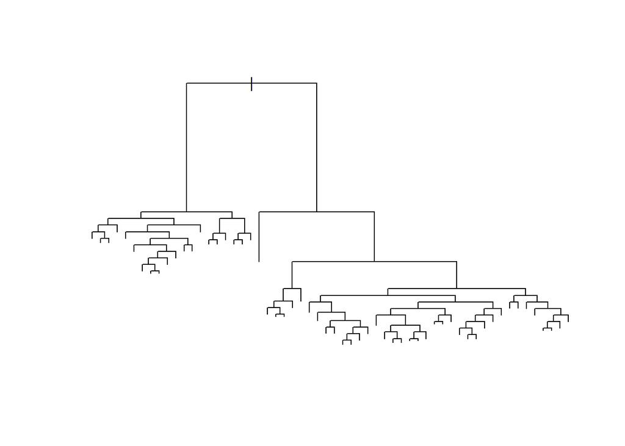

```r
set.seed(1)
modTree = rpart(diabetes ~ .,
                data = df,
                subset = train,
                method = "class",
                control = rpart.control(minsplit = 5, cp = 0.00001))
plot(modTree)
```

#### Potatura

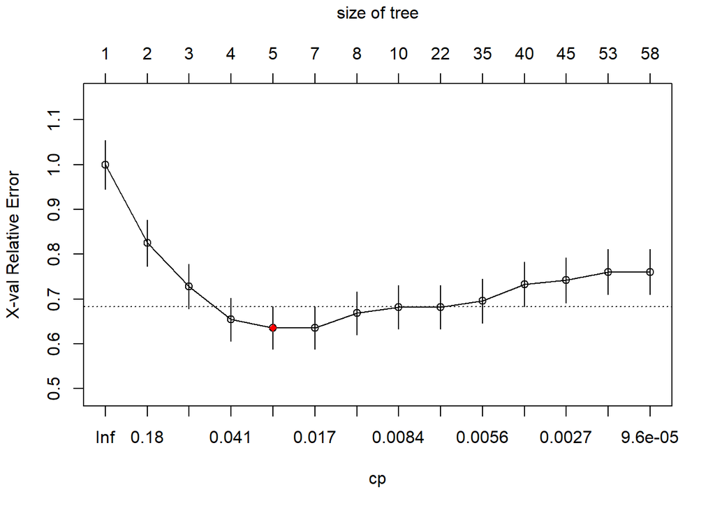

```r
{
  plotcp(modTree)
  points(x = which.min(modTree$cptable[,"xerror"]),
         y = min(modTree$cptable[,"xerror"]),
         col = "red",
         pch = 18)
}
```

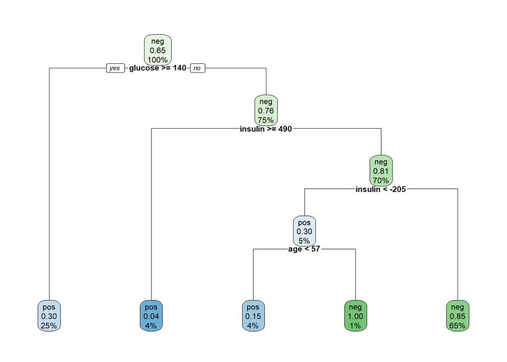

```r
modTree = prune(modTree,
                cp = modTree$cptable[which.min(modTree$cptable[,"xerror"]),"CP"])
rpart.plot(modTree, cex = .65)
```

## Confronto

### Accuratezza

```r
predGlm = factor(ifelse(predict(modGlmSP, newdata = df[-train,], type = "response") > .5, "pos", "neg"))
matConfGlm = confusionMatrix(predGlm, df$diabetes[-train])

predTree = factor(predict(modTree, newdata = df[-train,], type = "class"))
matConfTree = confusionMatrix(predTree, df$diabetes[-train])

data.frame("Regressione lineare" = round(matConfGlm$overall,3),
           "Albero di classificazione" = round(matConfTree$overall,3))
```

|  | Regressione.lineare | Albero.di.classificazione |
| --- | --- | --- |
| Accuracy | 0.143 | 0.773 |
| Kappa | -0.503 | 0.504 |
| AccuracyLower | 0.092 | 0.698 |
| AccuracyUpper | 0.208 | 0.836 |
| AccuracyNull | 0.669 | 0.669 |
| AccuracyPValue | 1.000 | 0.003 |
| McnemarPValue | 0.000 | 0.310 |

### Curva ROC

#### Modello di regressione logistica semiparemtirca

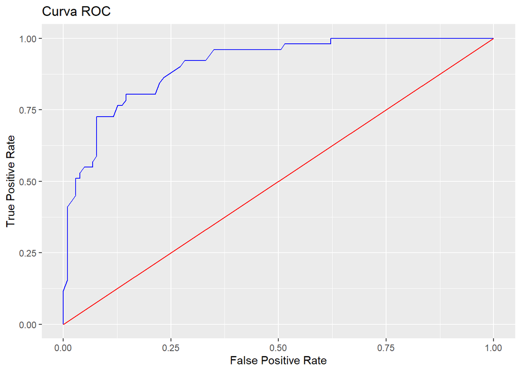

```r
plotROC(curvaROC(predict(modGlmSP, newdata = df[-train,], type = "response"),
                 df$diabetes[-train]))
```

#### Albero di classificazione

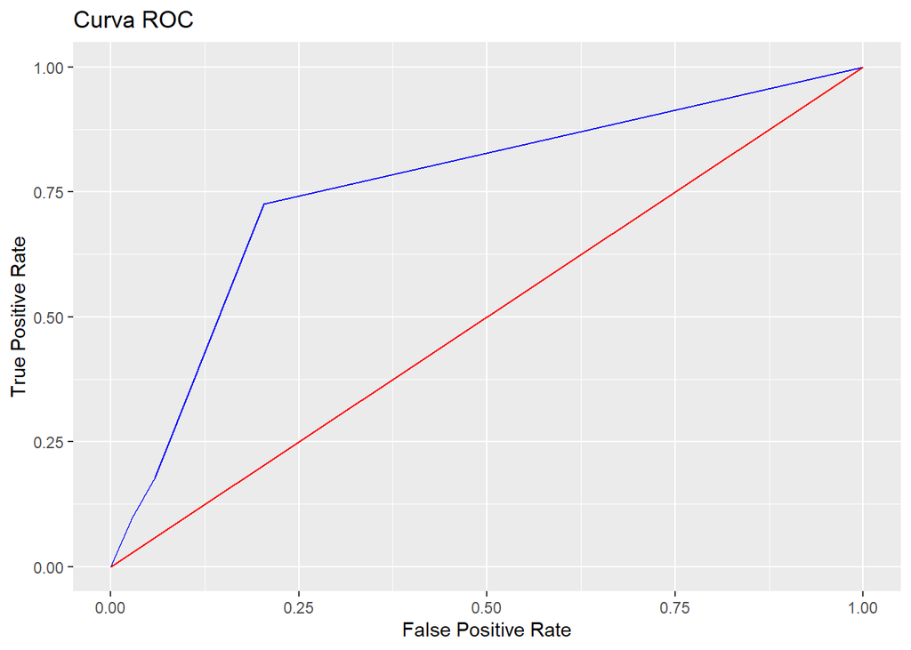

```r
plotROC(curvaROC(predict(modTree, newdata = df[-train,], type = "prob")[,2],
                 df$diabetes[-train]))
```

# Esercizio 3

### Importo i dati

```r
data("iris")
str(iris)
```

```
## 'data.frame':    150 obs. of  5 variables:
##  $ Sepal.Length: num  5.1 4.9 4.7 4.6 5 5.4 4.6 5 4.4 4.9 ...
##  $ Sepal.Width : num  3.5 3 3.2 3.1 3.6 3.9 3.4 3.4 2.9 3.1 ...
##  $ Petal.Length: num  1.4 1.4 1.3 1.5 1.4 1.7 1.4 1.5 1.4 1.5 ...
##  $ Petal.Width : num  0.2 0.2 0.2 0.2 0.2 0.4 0.3 0.2 0.2 0.1 ...
##  $ Species     : Factor w/ 3 levels "setosa","versicolor",..: 1 1 1 1 1 1 1 1 1 1 ...
```

## Albero di classificazione

L’albero di classificazione risulta essere con pochi nodi e quasi tutti i nodi terminali hanno solo classificazioni corrette. Questo fa pensare che le specie tra loro siano molto diverse, ovvero che la varianza tra le specie sia decisamente maggiore che la varianza nelle specie.

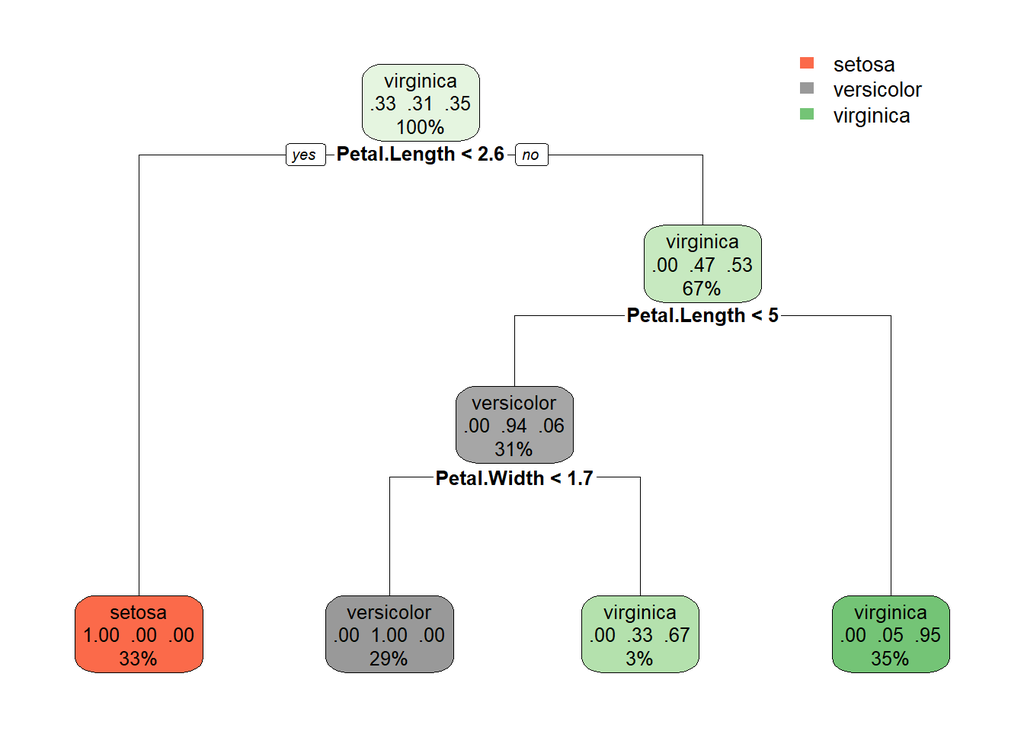

```r
# campionamento
set.seed(1)
train = sample(1:nrow(iris), .7 * nrow(iris))

# growing
modTree = rpart(Species ~ .,
                data = iris,
                subset = train,
                method = "class",
                control = rpart.control(minsplit = 5, cp = 0.00001))

# potatura
modTree = prune(modTree,
                cp = modTree$cptable[which.min(modTree$cptable[,"xerror"]),"CP"])
rpart.plot(modTree, cex = .8)
```

## Matrice di confusione

L’acccuratezza risulta molto elevata, anche se si intuiva già dal grafico soprastante. Durante il test solo una pianta è stata classificata erroneamente, questo porterà degli ottimi risultati per la specificità e la sensibilità delle varie classi che saranno quasi tutte uguali a 1.

```r
predTree = factor(predict(modTree, newdata = iris[-train,], type = "class"))
matConfTree = confusionMatrix(predTree, iris$Species[-train])
```

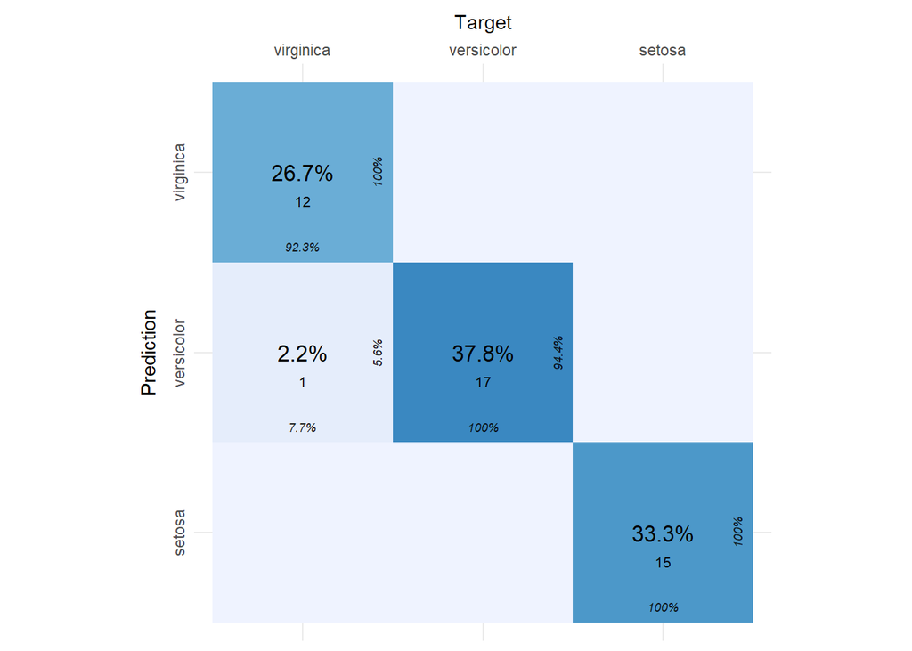

```r
cvms::plot_confusion_matrix(cvms::confusion_matrix(targets = iris$Species[-train],
                                                   predictions = predict(modTree,
                                                                         newdata = iris[-train,],
                                                                         type = "class"))$`Confusion Matrix`[[1]])
```